# SpotifyProject: Wolf Alice

Author

Ula Andrulyte

[figure not shown]

# Who are they?

> “Wolf Alice” is an alternative rock band, which founded in 2010. Known best as a duo made up of singer Ellie Rowsell and guitarist Joff Oddie, Wolf Alice have also featured drummer Joel Amey and bassist Theo Ellis since 2012. The band takes its name from “Wolf-Alice,” a late-seventies short story by Angela Carter. The story, a variation on “Little Red Riding Hood” and “Through the Looking-Glass,” is about a feral girl who is raised by wolves.

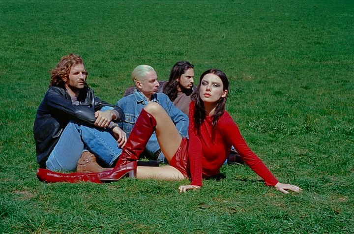

## Studio Albums

> 2015: My Love is Cool

> 2017: Visions of A Life

> 2021: Blue Weekend

> 2025: The Clearing

> The analysis will focus on the first three albums as the data set used was curated in 2023. The use of RStudio will aim to examine the variables from these albums.

### Discography

[video not shown]

“Lipstick On The Glass” is the third track on Wolf Alice’s third full length album, Blue Weekend. The track is about restarting or rejoining a relationship, despite the betrayal that has taken it apart.

[video not shown]

“The Last Man on Earth” is the lead single from Wolf Alice’s third studio album, Blue Weekend, which was released on June 4th, 2021. The song was officially premiered on February 24th, 2021 on BBC Radio One.

[video not shown]

This bass-driven minimalist ballad speaks of the heartache after a break-up. Starting from the painful, yet relatable scenery of blasting Amy Winehouse’s waterworks factory in the bathtub, the singer emerges from the pain realizing that “there is only so much sulking the heart can take”.

[video not shown]

Ellie Rowsell on twitter (about Planet Hunter): “I wrote this after I got mash up one New Year’s Eve Lol”. Ellie also said on Radio X that it´s about “the feeling when you never wanna go to bed and don´t want the night to end”.

[video not shown]

“Don’t Delete the Kisses” is the 4th track and the second single from Wolf Alice’s sophomore studio album Visions of a Life. It made its debut on Beats 1 Radio on July 5, 2017 as a World Record.Rowsell said of the track that she wanted to try “one of those, you know, ‘head-out-the window on a long drive’ kind of tunes”.

#### Data Analysis

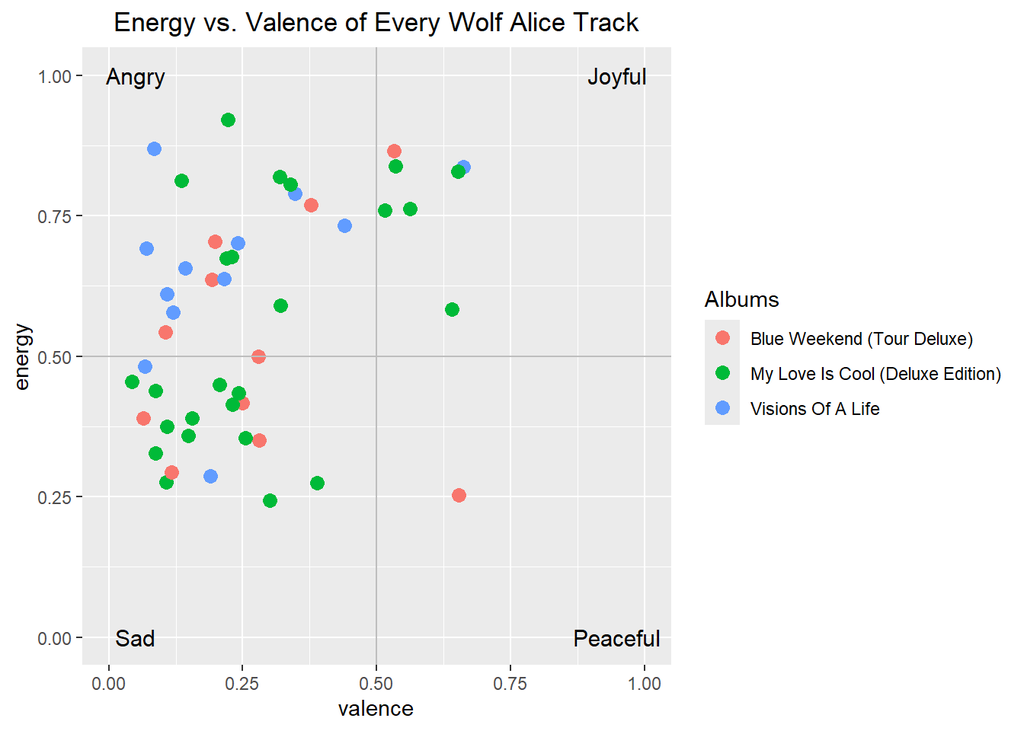

```r
library(gt)
library(readr)
library(knitr)
library(ggplot2)
df <- read.csv("Wolf Alice.csv")
#scatterplot
ggplot(df, aes(x = valence, y = energy, color = album_name)) +
  geom_point(size = 3) + #visualizing the individual tracks
  xlim(0,1) + #changing the scale to show the entire theoretical range
  ylim(0,1) +
  labs(color = "Albums", title = "Energy vs. Valence of Every Wolf Alice Track") +
  theme(plot.title = element_text(hjust = 0.5)) + #changing and adding the labels
  geom_hline(yintercept= 0.5, color="grey") + #creating quartiles
  geom_vline(xintercept= 0.5, color="grey") +
  annotate("text", x = 0.05, y = 1, label = "Angry", size = 4) + #naming quartiles
  annotate("text", x = 0.95, y = 1, label = "Joyful", size = 4) +
  annotate("text", x = 0.05, y = 0, label = "Sad", size = 4) +
  annotate("text", x = 0.95, y = 0, label = "Peaceful", size = 4)
```

The albums Visions of a Life and Blue Weekend mostly fall in the the Sad and Angry categories, with some outliers. My Love is Cool has some more joyful tracks in comparison. Overall, the plot suggests that Wolf Alice’s music tends to be energetic with relatively lower valence, reflecting a strong but often moody or intense emotional style.

Analysing the Energy variable for each album:

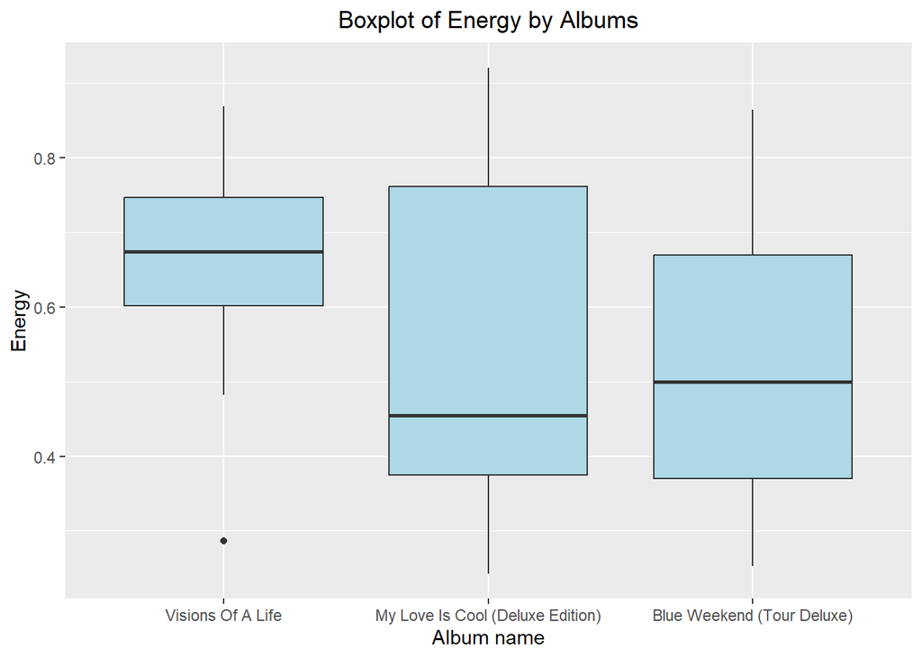

```r
ggplot(df, aes(x = factor(album_name, levels = c("Visions Of A Life", "My Love Is Cool (Deluxe Edition)", "Blue Weekend (Tour Deluxe)")), y=energy)) +  #chronilogical order of albums with level
  geom_boxplot() +
  labs(x="Album name", y="Energy", title = "Boxplot of Energy by Albums") +
  theme(plot.title = element_text(hjust = 0.5)) +
  geom_boxplot(fill = "lightblue")
```

As seen in the output, the boxplot shows differences in energy levels across the three albums. *Visions Of A Life* has the highest median energy, indicating it is generally the most energetic. *My Love Is Cool (Deluxe Edition)* shows the greatest variability, with energy levels ranging widely from low to high. *Blue Weekend (Tour Deluxe)* has a moderate median energy and moderate spread. Overall, *Visions Of A Life* appears the most consistently high-energy album, while *My Love Is Cool* is the most varied.

Analysing the Valence variable for each album:

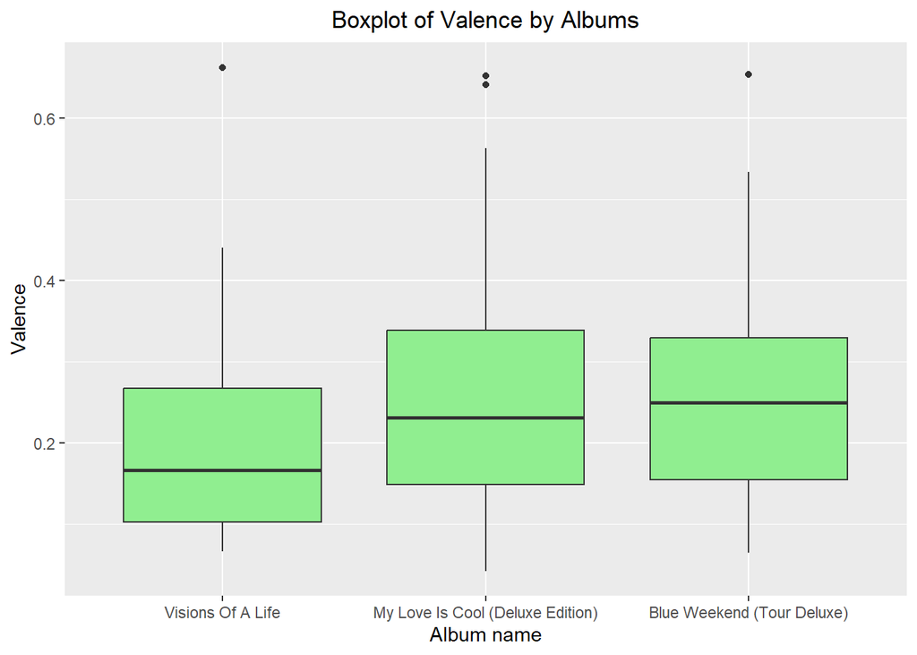

```r
#Boxplot of valence and album name
ggplot(df, aes(x = factor(album_name, levels = c("Visions Of A Life", "My Love Is Cool (Deluxe Edition)", "Blue Weekend (Tour Deluxe)")), y=valence)) +  #chronilogical order of albums with level
  geom_boxplot() +
  labs(x="Album name", y="Valence", title = "Boxplot of Valence by Albums") +
  theme(plot.title = element_text(hjust = 0.5)) +
  geom_boxplot(fill = "lightgreen")
```

Analysing the Energy of albums through a histogram:

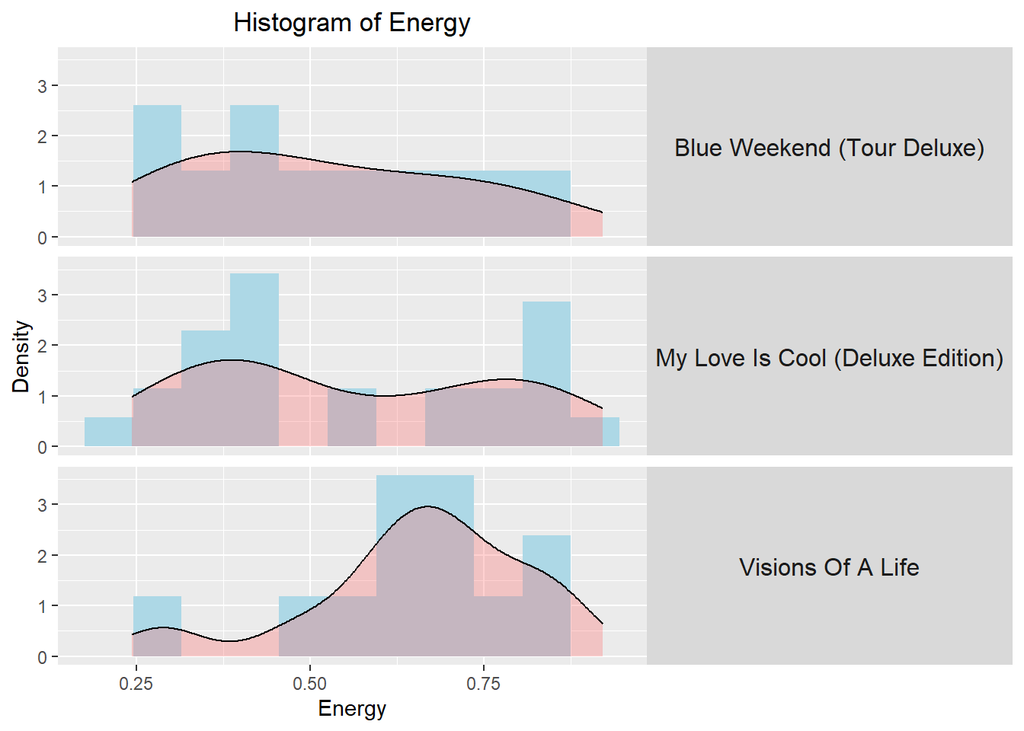

```r
## Histogram of energy
ggplot(df, aes(x = energy)) +
  geom_histogram(aes(y = after_stat(density)),
                 fill = "lightblue",
                 binwidth = 0.07) +
  geom_density(fill = "#FF6666", alpha = 0.3) +
  facet_grid(album_name ~ .) +
  labs(title = "Histogram of Energy", x = "Energy", y = "Density") +
  theme(
    plot.title = element_text(hjust = 0.5),
    strip.text.y = element_text(size = 12, angle = 0)
  )
```

Analysing the Valence of albums through a histogram:

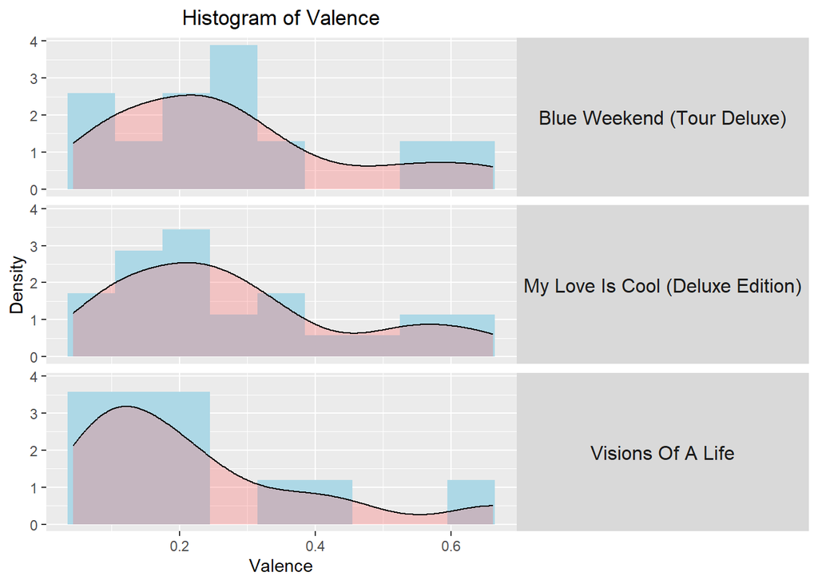

```r
## Histogram of Valence
ggplot(df, aes(x = valence)) +
  geom_histogram(aes(y = after_stat(density)),
                 fill = "lightblue",
                 binwidth = 0.07) +
  geom_density(fill = "#FF6666", alpha = 0.3) +
  facet_grid(album_name ~ .) +
  labs(title = "Histogram of Valence", x = "Valence", y = "Density") +
  theme(
    plot.title = element_text(hjust = 0.5),
    strip.text.y = element_text(size = 12, angle = 0)
  )
```

The figure highlights how the emotional tone of each Wolf Alice album differs by showing how their songs are distributed across the valence scale. *Blue Weekend* clusters mostly in the low‑to‑mid range, suggesting a reflective or bittersweet mood rather than bright positivity. *My Love Is Cool* spreads widely across the full range, showing the greatest emotional variety, from darker tracks to more uplifting ones. *Visions of a Life* leans strongly toward lower valence, with most songs sitting in the darker, more tense emotional space. Together, the three panels show a clear contrast in how each album expresses mood and emotional color.

Plotting the relationship between energy and valence through a linear regression:

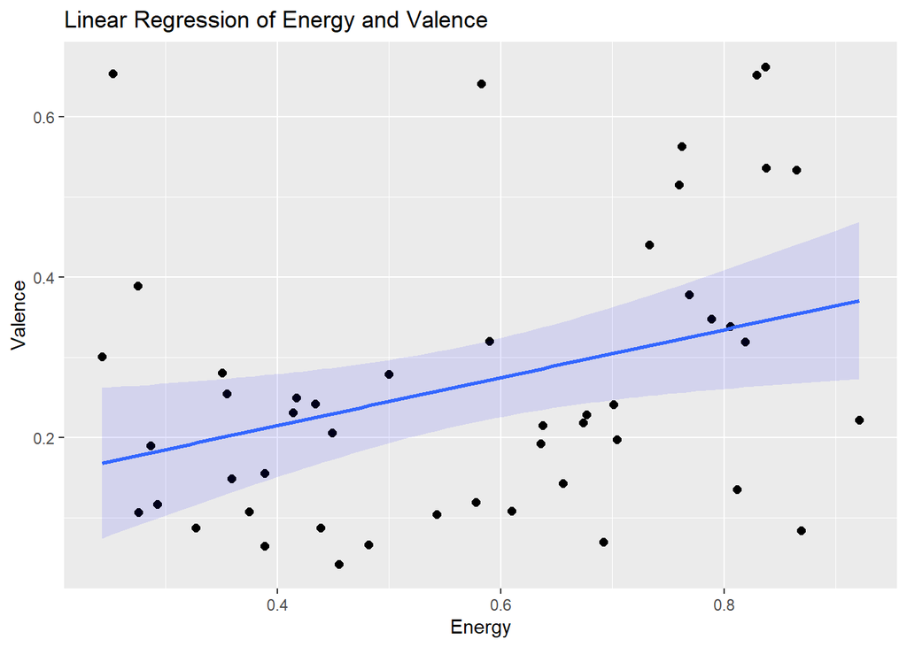

```r
## Linear regression of energy and valence
ggplot(df, aes(x = energy, y = valence)) +
  geom_point(size = 2) +
  geom_smooth(method = "lm", alpha = 0.1, fill = "blue") +
  labs(title = "Linear Regression of Energy and Valence",
       x = "Energy",
       y = "Valence")
```

The scatter plot shows a clear but moderate positive relationship between Energy and Valence: as Energy increases, Valence tends to rise as well, though the points are widely dispersed around the regression line. This spread suggests that Energy alone is not a strong predictor of Valence, even if the general upward trend is consistent. The confidence band around the line reinforces this uncertainty, indicating that while the model captures a directional pattern, individual values vary substantially.

##### For more information see:

The official Wolf Alice website:https://www.wolfalice.co.uk/

The official Youtube channel: https://www.youtube.com/channel/UCE3uvMO3ERiFphvVX_ct3GA